# Sector Rotation In the Stock Market

Niyog

2025-11-04

**Introduction**

```
  Investors often talk about “money moving around the market” but what does that really mean? Over the past two decades, the U.S. stock market has gone through some of the most volatile periods in modern history. From the bursting of the dot-com bubble in the early 2000s, to the 2008 financial crisis, to the COVID-19 crash and recovery and finally the inflation driven rate hikes of 2022/2023. Through all of these, one thing has remained consistent: money never leaves the market, it simply rotates between sectors.

  This project explores how different sectors of the S&P 500 have performed during these major market cycles. We’ll look at which sectors investors fled to during crashes and which ones led the recoveries, painting a picture of how capital shifts between defensive and cyclical parts of the economy.
```

First, I will load the data for all S&P 500 sector ETFs from Yahoo Finance and save it under a new variable.  
Each ticker (like **XLK**, **XLF**, or **XLE**) represents one major sector of the S&P 500.  
We’ll collect daily price data from **2000–2025**.

```r
# Reading sector ETF data from Yahoo Finance
# Using tidyquant to pull multiple tickers at once

etfs <- c("XLK","XLF","XLV","XLE","XLY","XLP","XLI","XLU","XLB","XLRE","XLC")

sector_data <- tq_get(etfs,
                      from = "2000-01-01",
                      to   = "2025-12-31") %>%
  group_by(symbol)

glimpse(sector_data)
```

```
## Rows: 62,934
## Columns: 8
## Groups: symbol [11]
## $ symbol   <chr> "XLK", "XLK", "XLK", "XLK", "XLK", "XLK", "XLK", "XLK", "XLK"…
## $ date     <date> 2000-01-03, 2000-01-04, 2000-01-05, 2000-01-06, 2000-01-07, …
## $ open     <dbl> 55.62500, 54.00000, 51.75000, 51.25000, 49.62500, 53.00000, 5…
## $ high     <dbl> 55.62500, 54.75000, 53.06250, 52.09375, 51.00000, 53.43750, 5…
## $ low      <dbl> 53.50000, 52.31250, 50.12500, 49.62500, 49.12500, 52.06250, 5…
## $ close    <dbl> 55.43750, 52.62500, 51.84375, 50.12500, 51.00000, 52.93750, 5…
## $ volume   <dbl> 938100, 545500, 1906000, 1670000, 686000, 1020500, 1411300, 1…
## $ adjusted <dbl> 41.36669, 39.26806, 38.68510, 37.40261, 38.05550, 39.50124, 3…
```

```r
unique(sector_data$symbol)
```

```
##  [1] "XLK"  "XLF"  "XLV"  "XLE"  "XLY"  "XLP"  "XLI"  "XLU"  "XLB"  "XLRE"
## [11] "XLC"
```

**Check for missing values** Let’s check if there are any missing values.

```r
#to check if there are any missing values in the dataset.
colSums(is.na(sector_data))
```

```
##   symbol     date     open     high      low    close   volume adjusted
##        0        0        0        0        0        0        0        0
```

So that means there are no missing data.

**Extracting Key Columns**

Since the dataset contains no missing values, the next step is to extract only the variables that are essential for our analysis. Keeping unnecessary fields adds noise and makes the workflow less efficient. For this project, the core columns are:

**Symbol** – identifies the ETF/sector associated with each observation

**Date** – the corresponding trading date

**Adjusted** – the adjusted closing price, which is the most reliable metric for time-series and return analysis.

These variables provide all the information required for analyzing sector performance over time.

```r
sector_data <- sector_data %>%
  select(symbol, date, adjusted)
glimpse(sector_data)
```

```
## Rows: 62,934
## Columns: 3
## Groups: symbol [11]
## $ symbol   <chr> "XLK", "XLK", "XLK", "XLK", "XLK", "XLK", "XLK", "XLK", "XLK"…
## $ date     <date> 2000-01-03, 2000-01-04, 2000-01-05, 2000-01-06, 2000-01-07, …
## $ adjusted <dbl> 41.36669, 39.26806, 38.68510, 37.40261, 38.05550, 39.50124, 3…
```

**Creating a “Year” Column**

With the essential variables extracted, the next step is to create a year column. This allows us to group and compare performance on an annual basis, making year-over-year analysis more meaningful.

```r
library(lubridate)
sector_data <- sector_data %>%
  mutate(year = year(date))
glimpse(sector_data)
```

```
## Rows: 62,934
## Columns: 4
## Groups: symbol [11]
## $ symbol   <chr> "XLK", "XLK", "XLK", "XLK", "XLK", "XLK", "XLK", "XLK", "XLK"…
## $ date     <date> 2000-01-03, 2000-01-04, 2000-01-05, 2000-01-06, 2000-01-07, …
## $ adjusted <dbl> 41.36669, 39.26806, 38.68510, 37.40261, 38.05550, 39.50124, 3…
## $ year     <dbl> 2000, 2000, 2000, 2000, 2000, 2000, 2000, 2000, 2000, 2000, 2…
```

Now we can easily group data by year later.

**Calculating Daily Returns** This step generates a new column **daily_return** which captures day-to-day percentage cahnge in teh adjusted closing price of each ETF. By calculating how much price moves in a trading day, we can measure short term performance, identify volatility patterns and prepare data for more advanced analysis.

```r
sector_data <- sector_data %>%
  group_by(symbol) %>%
  arrange(date) %>%
  mutate(daily_return = (adjusted - lag(adjusted)) / lag(adjusted))
glimpse(sector_data)
```

```
## Rows: 62,934
## Columns: 5
## Groups: symbol [11]
## $ symbol       <chr> "XLK", "XLF", "XLV", "XLE", "XLY", "XLP", "XLI", "XLU", "…
## $ date         <date> 2000-01-03, 2000-01-03, 2000-01-03, 2000-01-03, 2000-01-…
## $ adjusted     <dbl> 41.36669, 11.18687, 20.61217, 13.51303, 22.39116, 12.3050…
## $ year         <dbl> 2000, 2000, 2000, 2000, 2000, 2000, 2000, 2000, 2000, 200…
## $ daily_return <dbl> NA, NA, NA, NA, NA, NA, NA, NA, NA, -0.050732338, -0.0437…
```

This creates a new column **daily_return** for each ETF, showing its daily percentage change.

**Removing NA values** Since the first trading day for each ETF has no prior price to compare against, its daily_return value is NA. These rows do not contribute to our analysis, so we remove them to keep the dataset clean.

```r
sector_data <- sector_data %>%
  drop_na(daily_return)
glimpse(sector_data)
```

```
## Rows: 62,923
## Columns: 5
## Groups: symbol [11]
## $ symbol       <chr> "XLK", "XLF", "XLV", "XLE", "XLY", "XLP", "XLI", "XLU", "…
## $ date         <date> 2000-01-04, 2000-01-04, 2000-01-04, 2000-01-04, 2000-01-…
## $ adjusted     <dbl> 39.26806, 10.69783, 20.14445, 13.25867, 21.71757, 11.9585…
## $ year         <dbl> 2000, 2000, 2000, 2000, 2000, 2000, 2000, 2000, 2000, 200…
## $ daily_return <dbl> -0.050732338, -0.043715640, -0.022691815, -0.018823194, -…
```

Now we can confirm that all NA values have been removed, leaving us with a clean set of valid daily returns for analysis.

**Let’s see if each ETF has data for multiple years**

```r
sector_data %>%
  group_by(symbol) %>%
  summarise(start = min(date), end = max(date))
```

```
## # A tibble: 11 × 3
##    symbol start      end
##    <chr>  <date>     <date>
##  1 XLB    2000-01-04 2025-11-10
##  2 XLC    2018-06-20 2025-11-10
##  3 XLE    2000-01-04 2025-11-10
##  4 XLF    2000-01-04 2025-11-10
##  5 XLI    2000-01-04 2025-11-10
##  6 XLK    2000-01-04 2025-11-10
##  7 XLP    2000-01-04 2025-11-10
##  8 XLRE   2015-10-09 2025-11-10
##  9 XLU    2000-01-04 2025-11-10
## 10 XLV    2000-01-04 2025-11-10
## 11 XLY    2000-01-04 2025-11-10
```

```r
glimpse(sector_data)
```

```
## Rows: 62,923
## Columns: 5
## Groups: symbol [11]
## $ symbol       <chr> "XLK", "XLF", "XLV", "XLE", "XLY", "XLP", "XLI", "XLU", "…
## $ date         <date> 2000-01-04, 2000-01-04, 2000-01-04, 2000-01-04, 2000-01-…
## $ adjusted     <dbl> 39.26806, 10.69783, 20.14445, 13.25867, 21.71757, 11.9585…
## $ year         <dbl> 2000, 2000, 2000, 2000, 2000, 2000, 2000, 2000, 2000, 200…
## $ daily_return <dbl> -0.050732338, -0.043715640, -0.022691815, -0.018823194, -…
```

**Now everything looks good and the data’s all set. Time to start asking some questions.**

**1. How have different sectors performed over time?** Over the years, sector ETFs have shown unique patterns of growth and decline shaped by economic cycles and investor sentiment. By visualizing their performance over time, we can spot which sectors led the market and which lagged behind.

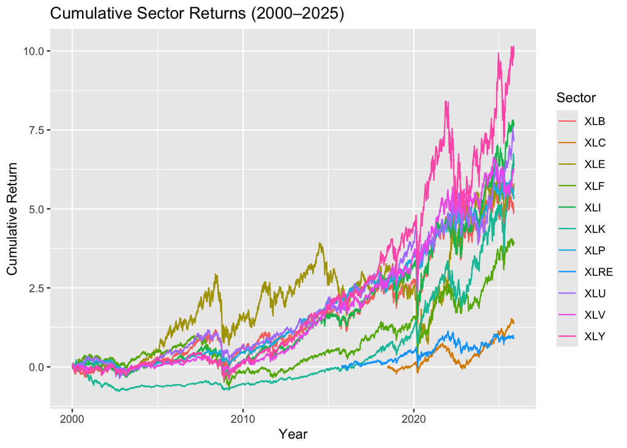

```r
sector_trend <- sector_data %>%
  group_by(symbol) %>%
  arrange(date) %>%
  mutate(cumulative_return = (adjusted / first(adjusted)) - 1)

ggplot(sector_trend, aes(x=date, y=cumulative_return, color=symbol)) +
  geom_line() +
  labs(title="Cumulative Sector Returns (2000–2025)",
       y="Cumulative Return",
       x="Year",
       color="Sector")
```

**2. Which sectors performed best and worst each year?** Every year different market conditions favor certain sectors. By comparing annual returns, we can see which sectors led the market and which lagged behind.

```r
#Calculating average yearly return
yearly_avg <- sector_data %>%
  group_by(symbol, year) %>%
  summarise(avg_return = mean(daily_return, na.rm = TRUE))
```

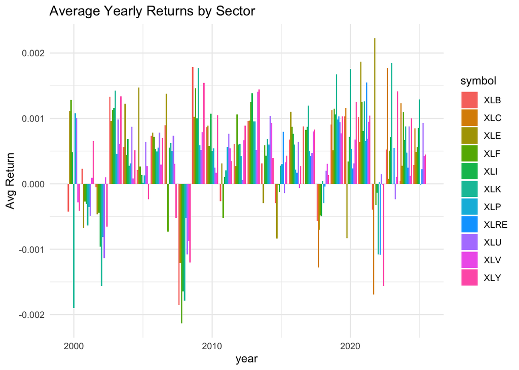

```r
ggplot(yearly_avg, aes(x=year, y=avg_return, fill=symbol)) +
  geom_col(position="dodge") +
  labs(title="Average Yearly Returns by Sector", y="Avg Return") +
  theme_minimal()
```

**3. How did sectors behave around major market events?** Major market events often reveal how different sectors respond to stress and recovery. Here, we examine sector trends around crises like the 2008 recession and the 2020 pandemic.

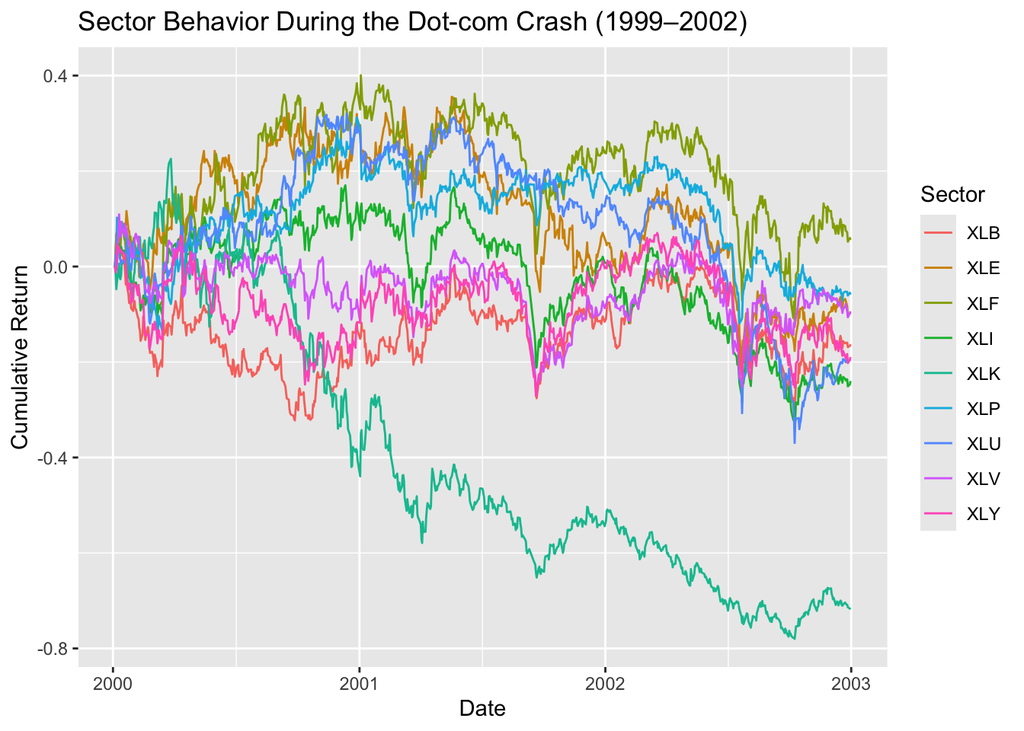

```r
dotcom <- filter(sector_trend, year >= 1999 & year <= 2002)
crash2008 <- filter(sector_trend, year >= 2007 & year <= 2009)
covid <- filter(sector_trend, year >= 2019 & year <= 2021)

#dotcom crash
ggplot(dotcom, aes(x=date, y=cumulative_return, color=symbol)) +
  geom_line() +
  labs(title="Sector Behavior During the Dot-com Crash (1999–2002)",
       x="Date", y="Cumulative Return", color="Sector")
```

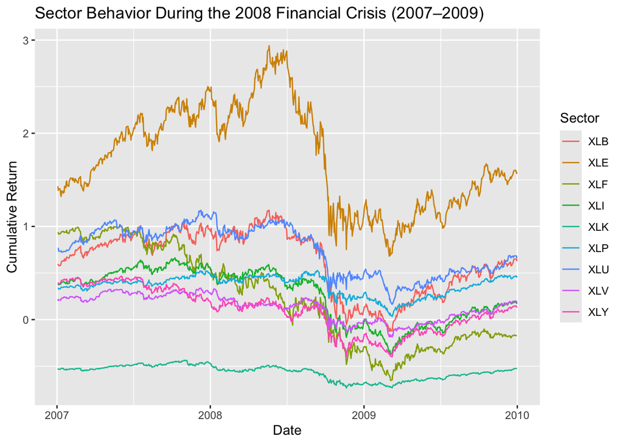

```r
#financial crisis of 2008
ggplot(crash2008, aes(x=date, y=cumulative_return, color=symbol)) +
  geom_line() +
  labs(title="Sector Behavior During the 2008 Financial Crisis (2007–2009)",
       x="Date", y="Cumulative Return", color="Sector")
```

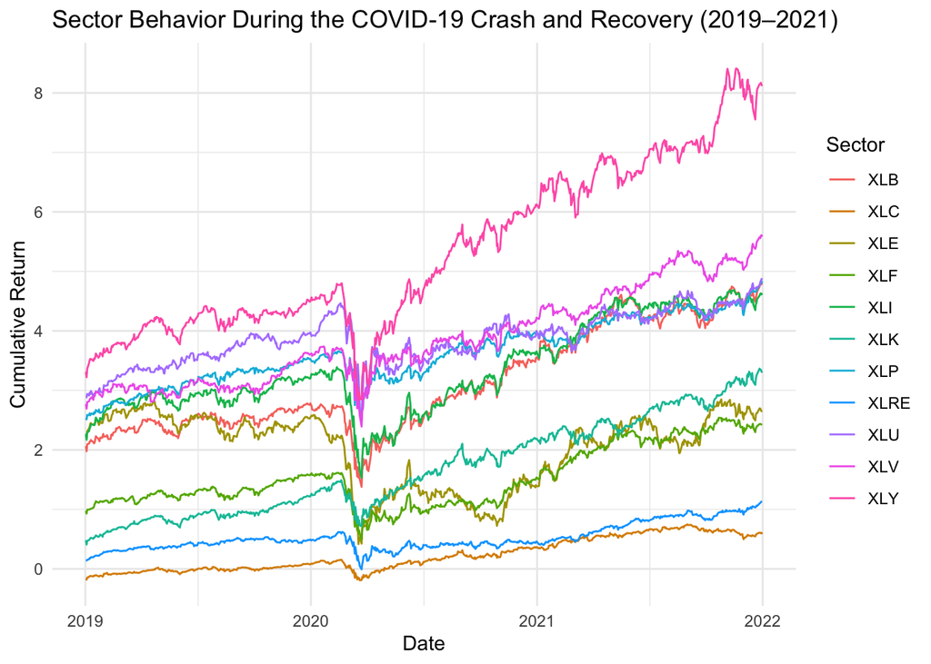

```r
#Pandemic
ggplot(covid, aes(x=date, y=cumulative_return, color=symbol)) +
  geom_line() +
  labs(title="Sector Behavior During the COVID-19 Crash and Recovery (2019–2021)",
       x="Date", y="Cumulative Return", color="Sector") +
  theme_minimal()
```

2008 Financial Crisis The 2008 crisis caused sharp declines across nearly all sectors with Financials (XLF) among the hardest hit due to the banking collapse. Energy (XLE) initially outperformed but later dropped as demand weakened.

COVID Crash The pandemic triggered a swift market crash in early 2020, followed by one of the fastest recoveries in history. Technology (XLK) and Consumer Discretionary (XLY) led the rebound as digital adoption increased during the lockdown period. Energy (XLE) initially collapsed due to reduced demand but rebounded later with economic reopening. Defensive sectors like Utilities (XLU) and Health Care (XLV) showed resilience throughout. This reflects investor preference for stability during uncertainty.

**4. Are some sectors more volatile than others?** As we’ve seen in the previous graphs, different sectors move uniquely over time. Here, we analyze and compare the volatility of each sector to understand which ones experience greater fluctuations.

```r
#SD of daily returns
volatility <- sector_data %>%
  group_by(symbol, year) %>%
  summarise(sd_return = sd(daily_return, na.rm = TRUE))
```

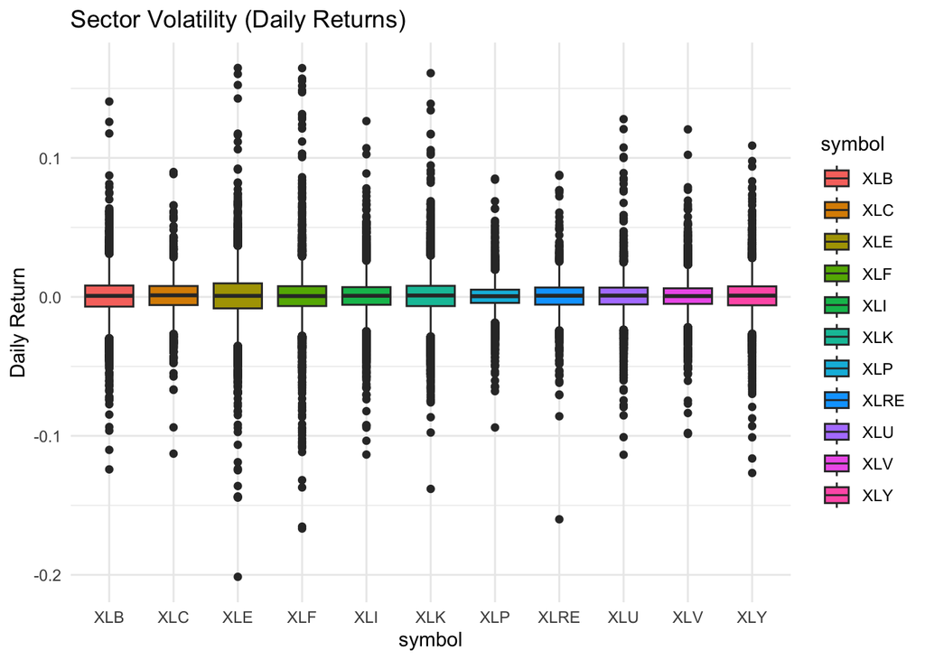

```r
#Boxplot
ggplot(sector_data, aes(x=symbol, y=daily_return, fill=symbol)) +
  geom_boxplot() +
  labs(title="Sector Volatility (Daily Returns)", y="Daily Return") +
  theme_minimal()
```

This chart shows how much each sector’s returns tend to swing on a daily basis. Energy (XLE) and Financials (XLF) are the most volatile, often reacting sharply to market changes. On the other hand, Utilities (XLU) and Consumer Staples (XLP) stay relatively calm, reflecting their steadier nature. Overall, growth sectors move more wildly while defensive ones are stable.

**How do sectors correlate with eachother?**

Understanding how sectors move in relation to each other helps reveal market connections and diversification opportunities. Here, we see the correlations using a heatmap.

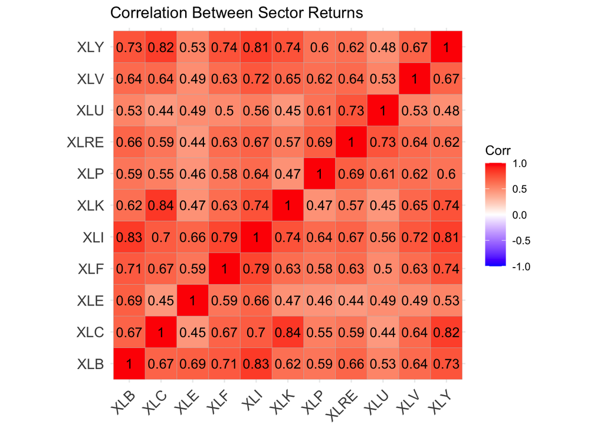

```r
#correlation
wide_returns <- sector_data %>%
  select(date, symbol, daily_return) %>%
  spread(symbol, daily_return)

cor_matrix <- cor(wide_returns[,-1], use="pairwise.complete.obs")

#heatmap
library(ggcorrplot) #for heatmap
ggcorrplot(cor_matrix, lab = TRUE, title="Correlation Between Sector Returns")
```

The heatmap shows that most sectors are strongly positively correlated, meaning they tend to move together. Industrial (XLI), Financials (XLF), and Consumer Discretionary (XLY) show some of the highest correlations, reflecting their sensitivity to overall economic trends. Defensive sectors like Utilities (XLU) and Consumer Staples (XLP) have lower correlations, suggesting they behave more independently during different market conditions. Overall, this indicates that while most sectors follow the broader market direction, stable ones can offer some diversification benefits.